# Murder Accountability Project

The [Murder Accountability Project (MAP)](http://www.murderdata.org/) is a nonprofit organisation publishing data on solved and unsolved homicides in the United States. The information is acquired from federal, state and local governments and includes murders from the FBI's Supplementary Homicide Report as well as more than 33,000 homicides obtained through the Freedom of Information Act for homicides not reported to the Justice Department.

The information gathered by MAP is the most complete data on U.S. homicides available anywhere.

There are two datasets:

- Uniform Crime Report UCR (from 1965 onwards)
- Supplementary Homicide Report SHR (from 1976 onwards)

The UCR summarises all homicides and homicide clearances reported from 1965 to the present, making it the ideal dataset to study clearance rates.

The SHR dataset includes the age, race, sex and ethnicity of victims as well as the weapon used and the circumstances surrounding the killing. Names are not reported, but the month, year, victim's demographic characteristics and the reporting agency are included. Police also report demographic information about offenders when the killer has been arrested, however, reports are rarely updated which means this information might be missing where arrests were made after the SHR was filed. It is also for this reason that the SHR is not a reliable source when studying clearance rates - between 5 and 10 percent of homicides noted as unsolved at the time of reporting to the SHR were solved later.

```python
import pandas as pd
import numpy as np
import matplotlib.pyplot as plt
import operator
import folium
import branca.colormap as cm
```

```python
pd.set_option('max_columns', None)
```

## Uniform Crime Reporting

```python
# Uniform Crime Report
ucr = pd.read_csv("datasets/MAP/UCR65_20.csv")
```

```python
ucr.head()   # MRD: number of murders, CLR: number of solved ("cleared") murders
```

|  | ORI | Name | YEAR | MRD | CLR | State | County | Agency |
| --- | --- | --- | --- | --- | --- | --- | --- | --- |
| 0 | AK00101 | ANCHORAGE | 1965 | 7 | 6 | Alaska | Anchorage, AK | Anchorage |
| 1 | AK00101 | ANCHORAGE | 1966 | 18 | 16 | Alaska | Anchorage, AK | Anchorage |
| 2 | AK00101 | ANCHORAGE | 1967 | 1 | 1 | Alaska | Anchorage, AK | Anchorage |
| 3 | AK00101 | ANCHORAGE | 1968 | 7 | 5 | Alaska | Anchorage, AK | Anchorage |
| 4 | AK00101 | ANCHORAGE | 1969 | 7 | 4 | Alaska | Anchorage, AK | Anchorage |

```python
group_sums = ucr.groupby("YEAR")[["MRD","CLR"]].agg(np.sum)
```

```python
# helper function for visualising homicide clearance
def plot_homicide_clearance(grouped_data, chart_title):

    fig, ax = plt.subplots(figsize=(10, 6))

    labels = grouped_data.index

    ax.bar(labels, grouped_data["MRD"], label="MRD")
    ax.bar(labels, grouped_data["CLR"], label="CLR")

    ax.set_title(chart_title)
    ax.legend()

    plt.show()
```

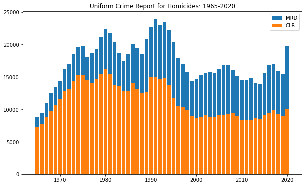

```python
plot_homicide_clearance(group_sums, "Uniform Crime Report for Homicides: 1965-2020")
```

The total height of the bars in above bar chart (blue and orange parts combined) shows us the total number of murders reported in a particular year. The orange portion represents the homicides that were cleared, and the blue zone - the difference between total and solved murders - highlights the number of homicides per year that went unsolved.

```python
total_murders = sum(ucr["MRD"])
total_cleared = sum(ucr["CLR"])
percentage_cleared = round(total_cleared / total_murders * 100, 2)
```

```python
print(f"The total number of homicides in our data is {total_murders}. {total_cleared} homicides \
({percentage_cleared}%) have been cleared, while {total_murders-total_cleared} - {100 - percentage_cleared}% \
of all reported homicides from 1965 to 2020 - remain unsolved.")
```

```
The total number of homicides in our data is 967240. 636541 homicides (65.81%) have been cleared, while 330699 - 34.19% of all reported homicides from 1965 to 2020 - remain unsolved.
```

Let's next take a look at homicide clearance rates over time.

```python
group_sums["%_Cleared"] = group_sums["CLR"] / group_sums["MRD"]
group_sums.sample(5)
```

| YEAR | MRD | CLR | %_Cleared |
| --- | --- | --- | --- |
| 1997 | 16931 | 10286 | 0.607525 |
| 1965 | 8739 | 7292 | 0.834420 |
| 1999 | 14361 | 8991 | 0.626071 |
| 1970 | 14361 | 11605 | 0.808091 |
| 2019 | 15449 | 8905 | 0.576413 |

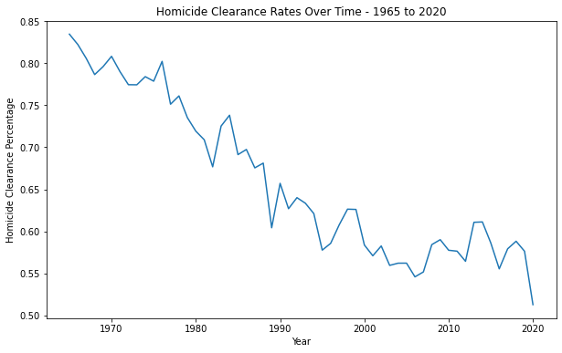

```python
group_sums.plot.line(y="%_Cleared", xlabel="Year", ylabel="Homicide Clearance Percentage", figsize=(10,6),
                     title="Homicide Clearance Rates Over Time - 1965 to 2020", legend=False);
```

```python
percentage_solved_2020 = round(group_sums.at[2020, "%_Cleared"] * 100, 2)
percentage_solved_2020
```

```
51.29
```

```python
print(f"Homicide clearance rates reached an all time low in 2020, with only {percentage_solved_2020}% of murders solved.")
```

```
Homicide clearance rates reached an all time low in 2020, with only 51.29% of murders solved.
```

In [this blog post](https://www.murderdata.org/2021/10/homicide-clearance-in-united-states.html?m=0), MAP share that they believe the decline in clearance rates is caused by a failure to give necessary resources to local police as well as a failure of political leaders to make solving homicides a priority.

## Supplementary Homicide Report

```python
# Supplementary Homicide Report
shr = pd.read_csv("datasets/MAP/SHR76_20.csv", low_memory=False)
```

```python
shr.sample(5)
```

|  | ID | CNTYFIPS | Ori | State | Agency | Agentype | Source | Solved | Year | StateName | Month | Incident | ActionType | Homicide | Situation | VicAge | VicSex | VicRace | VicEthnic | OffAge | OffSex | OffRace | OffEthnic | Weapon | Relationship | Circumstance | Subcircum | VicCount | OffCount | … |
| --- | --- | --- | --- | --- | --- | --- | --- | --- | --- | --- | --- | --- | --- | --- | --- | --- | --- | --- | --- | --- | --- | --- | --- | --- | --- | --- | --- | --- | --- | --- |
| 226471 | 198602001FL04400 | Monroe, FL | FL04400 | Florida | Monroe County | Sheriff | FBI | No | 1986 | NaN | February | 1 | Normal update | Murder and non-negligent manslaughter | Single victim/unknown offender(s) | 27 | Male | White | Unknown or not reported | 999 | Unknown | Unknown | Unknown or not reported | Blunt object - hammer, club, etc | Relationship not determined | Narcotic drug laws | NaN | 0 | 0 | … |
| 546567 | 200110049NY03030 | New York, NY | NY03030 | New York | New York | Municipal police | FBI | No | 2001 | NaN | October | 49 | Normal update | Murder and non-negligent manslaughter | Single victim/unknown offender(s) | 22 | Male | Black | Unknown or not reported | 999 | Unknown | Unknown | Unknown or not reported | Handgun - pistol, revolver, etc | Relationship not determined | Circumstances undetermined | NaN | 0 | 0 | … |
| 596969 | 202007013OHCLP00 | Cuyahoga, OH | OHCLP00 | Ohio | Cleveland | Municipal police | FBI | No | 2020 | OHIO | July | 13 | Normal update | Murder and non-negligent manslaughter | Multiple victims/unknown offender(s) | 26 | Male | Black | Not of Hispanic origin | 999 | Unknown | Unknown | Unknown or not reported | Firearm, type not stated | Relationship not determined | Circumstances undetermined | NaN | 1 | 0 | … |
| 788152 | 199106001VA04600 | Isle of Wight, VA | VA04600 | Virginia | Isle of Wight County | Sheriff | FBI | Yes | 1991 | NaN | June | 1 | Normal update | Murder and non-negligent manslaughter | Single victim/single offender | 30 | Female | White | Not of Hispanic origin | 44 | Male | White | Not of Hispanic origin | Shotgun | Acquaintance | Other arguments | NaN | 0 | 0 | … |
| 709336 | 201801001TX01500 | Bexar, TX | TX01500 | Texas | Bexar County | Sheriff | FBI | Yes | 2018 | NaN | January | 1 | Normal update | Murder and non-negligent manslaughter | Single victim/single offender | 19 | Male | White | Hispanic origin | 19 | Male | White | Hispanic origin | Handgun - pistol, revolver, etc | Stranger | Narcotic drug laws | NaN | 0 | 0 | … |

```python
shr.shape
```

```
(827219, 31)
```

```python
shr.info()
```

```
<class 'pandas.core.frame.DataFrame'>
RangeIndex: 827219 entries, 0 to 827218
Data columns (total 31 columns):
 #   Column        Non-Null Count   Dtype
---  ------        --------------   -----
 0   ID            827219 non-null  object
 1   CNTYFIPS      827219 non-null  object
 2   Ori           827219 non-null  object
 3   State         827219 non-null  object
 4   Agency        827219 non-null  object
 5   Agentype      827219 non-null  object
 6   Source        827219 non-null  object
 7   Solved        827219 non-null  object
 8   Year          827219 non-null  int64
 9   StateName     22468 non-null   object
```

[output cut: 23 more lines]

```python
# checking for duplicate rows
sum(shr.duplicated(keep=False))
```

```
4427
```

```python
# example duplicated rows
duplicated_rows = shr[shr.duplicated(keep=False)]
duplicated_rows.head(4)
```

|  | ID | CNTYFIPS | Ori | State | Agency | Agentype | Source | Solved | Year | StateName | Month | Incident | ActionType | Homicide | Situation | VicAge | VicSex | VicRace | VicEthnic | OffAge | OffSex | OffRace | OffEthnic | Weapon | Relationship | Circumstance | Subcircum | VicCount | OffCount | … |
| --- | --- | --- | --- | --- | --- | --- | --- | --- | --- | --- | --- | --- | --- | --- | --- | --- | --- | --- | --- | --- | --- | --- | --- | --- | --- | --- | --- | --- | --- | --- |
| 4006 | 197709001AL00101 | Jefferson, AL | AL00101 | Alabama | Bessemer | Municipal police | FBI | Yes | 1977 | NaN | September | 1 | Adjustment | Murder and non-negligent manslaughter | Multiple victims/single offender | 27 | Female | Black | Unknown or not reported | 31 | Male | Black | Unknown or not reported | Handgun - pistol, revolver, etc | Stranger | Lovers triangle | NaN | 1 | 0 | … |
| 4007 | 197709001AL00101 | Jefferson, AL | AL00101 | Alabama | Bessemer | Municipal police | FBI | Yes | 1977 | NaN | September | 1 | Adjustment | Murder and non-negligent manslaughter | Multiple victims/single offender | 27 | Female | Black | Unknown or not reported | 31 | Male | Black | Unknown or not reported | Handgun - pistol, revolver, etc | Stranger | Lovers triangle | NaN | 1 | 0 | … |
| 4008 | 197709001AL00101 | Jefferson, AL | AL00101 | Alabama | Bessemer | Municipal police | FBI | Yes | 1977 | NaN | September | 1 | Adjustment | Murder and non-negligent manslaughter | Multiple victims/single offender | 27 | Male | Black | Unknown or not reported | 31 | Male | Black | Unknown or not reported | Handgun - pistol, revolver, etc | Stranger | Lovers triangle | NaN | 1 | 0 | … |
| 4009 | 197709001AL00101 | Jefferson, AL | AL00101 | Alabama | Bessemer | Municipal police | FBI | Yes | 1977 | NaN | September | 1 | Adjustment | Murder and non-negligent manslaughter | Multiple victims/single offender | 27 | Male | Black | Unknown or not reported | 31 | Male | Black | Unknown or not reported | Handgun - pistol, revolver, etc | Stranger | Lovers triangle | NaN | 1 | 0 | … |

```python
# dropping duplicate rows except for the first occurrence
shr.drop_duplicates(inplace=True, ignore_index=True)
```

```python
shr.shape
```

```
(824948, 31)
```

### Exploring the Data

#### Relationship

The most common relationship value in our data is "relationship not determined" - where we do know the relationship, murderers are most commonly acquaintances, strangers, or persons otherwise known to the victim.

```python
shr["Relationship"].value_counts()[:4]
```

```
Relationship not determined    319603
Acquaintance                   158731
Stranger                       121483
Other - known to victim         37797
Name: Relationship, dtype: int64
```

```python
murder_number = sum(shr["Relationship"].value_counts()[:4])
murder_percentage = round(murder_number / len(shr) * 100, 2)
print(f"These groups account for {murder_number} murders in total - {murder_percentage}% of murders in our data.")
```

```
These groups account for 637614 murders in total - 77.29% of murders in our data.
```

The other homicides have mainly been linked to offenders with close(r) relationships to the victims, such as family members, friends and partners.

```python
shr["Relationship"].value_counts()[4:]
```

```
Wife                       30167
Friend                     28270
Girlfriend                 21127
Son                        12900
Other family               12630
Husband                    12252
Boyfriend                   9598
Daughter                    9349
Neighbor                    8396
Brother                     7171
Father                      5985
Mother                      5829
In-law                      4940
Common-law wife             3339
Common-law husband          2720
Ex-wife                     2517
Stepfather                  1860
Sister                      1784
Homosexual relationship     1723
Stepson                     1568
Ex-husband                   914
Stepdaughter                 907
Employer                     610
Employee                     489
Stepmother                   289
Name: Relationship, dtype: int64
```

It is important to note that the `Relationship` column describes the relationship between offender and victim **from the offender's point of view** - if a husband murdered his wife for instance, the relationship as per our data is "Wife".

```python
shr[shr["Relationship"]=="Wife"][["Relationship", "VicSex", "OffSex"]].sample(3)
```

|  | Relationship | VicSex | OffSex |
| --- | --- | --- | --- |
| 823622 | Wife | Female | Male |
| 368131 | Wife | Female | Male |
| 778782 | Wife | Female | Male |

In other words, the `Relationship` column can be thought to **describe who the victim was**.

```python
# relationship "Son": a son was killed by his mother of father
shr[shr["Relationship"]=="Son"][["Relationship", "VicSex", "OffSex"]].sample(3)
```

|  | Relationship | VicSex | OffSex |
| --- | --- | --- | --- |
| 802062 | Son | Male | Female |
| 442098 | Son | Male | Male |
| 473930 | Son | Male | Male |

```python
# relationship "Boyfriend": a boyfriend was killed by his girlfriend (homosexual relationships are a separate option)
shr[shr["Relationship"]=="Boyfriend"][["Relationship", "VicSex", "OffSex"]].sample(3)
```

|  | Relationship | VicSex | OffSex |
| --- | --- | --- | --- |
| 738883 | Boyfriend | Male | Female |
| 505653 | Boyfriend | Male | Female |
| 144884 | Boyfriend | Male | Female |

Keeping this in mind, let's take a closer look at these close-relationship homicides:

```python
remaining_murders = len(shr) - murder_number
print("Murders linked to offenders with close(r) relationships to the victims: ", remaining_murders)
print("Percentage of these murders in our data: ", round(remaining_murders / len(shr) * 100, 2))
```

```
Murders linked to offenders with close(r) relationships to the victims:  187334
Percentage of these murders in our data:  22.71
```

We will plot a pie chart to visualise who most commonly falls victim to offenders they have a somewhat close relationship with.

To make the pie chart more readable, let's first combine victim groups with less than 5000 homicides per group together into one.

```python
relationship_vc_series = shr["Relationship"].value_counts()[4:]  # isolating the remaining relationships of interest
count = 0
relationships_list = []

for i in range(0, len(relationship_vc_series)):
    if relationship_vc_series[i] < 5000:
        count += relationship_vc_series[i]
        relationships_list.append(relationship_vc_series.index[i])

print(relationships_list)
print(count)
```

```
['In-law', 'Common-law wife', 'Common-law husband', 'Ex-wife', 'Stepfather', 'Sister', 'Homosexual relationship', 'Stepson', 'Ex-husband', 'Stepdaughter', 'Employer', 'Employee', 'Stepmother']
23660
```

```python
relationship_vc_series.drop(relationships_list, axis=0, inplace=True)  # drop individual relationships
relationship_vc_series["\n".join(relationships_list)] = count          # add grouped relationship
```

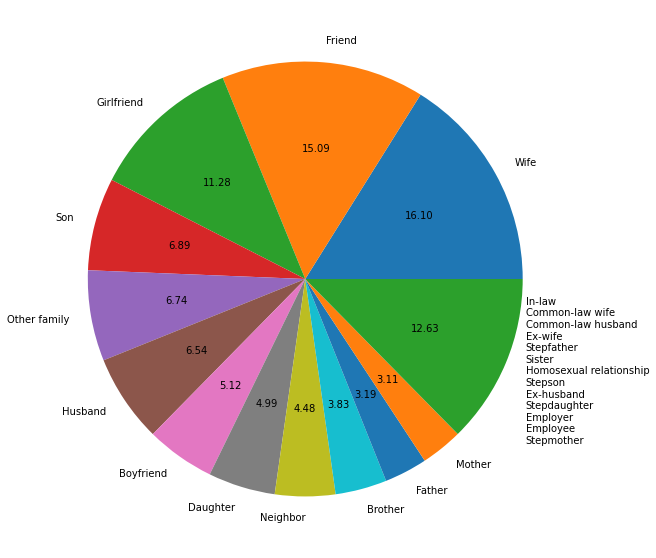

```python
plt.figure(figsize=(10,10))
relationship_vc_series.plot.pie(label="", autopct='%.2f')
```

A few interesting findings:

- Wives, friends, girlfriends and sons most commonly fall victim to offenders they are close with, namely their husbands, friends, boyfriends or parents (mother or father). Together, they represent almost 50% of close-relationship homicides.
- Children are more often killed by their parents than parents are killed by their children.
- Women are more often killed by their partners than men.

Before we move on, let's quickly check whether our data confirms the common believe that most murders are committed by offenders known to the victim.

```python
homicides_to_consider = len(shr) - shr["Relationship"].value_counts()[0]  # exclude "Relationship not determined"
homicides_to_consider
```

```
505345
```

```python
murdered_by_stranger = shr["Relationship"].value_counts()[2]
murdered_by_stranger_percent = round(murdered_by_stranger / homicides_to_consider *100, 2)
```

```python
print(f"Out of the {homicides_to_consider} homicides with established relationship between offender and victim, \
{murdered_by_stranger} murders representing {murdered_by_stranger_percent}% were committed by strangers. This means that \
the grand majority of homicides ({round(100-murdered_by_stranger_percent, 2)}%) were indeed committed by offenders \
to some extent known to the victim.")
```

```
Out of the 505345 homicides with established relationship between offender and victim, 121483 murders representing 24.04% were committed by strangers. This means that the grand majority of homicides (75.96%) were indeed committed by offenders to some extent known to the victim.
```

#### State

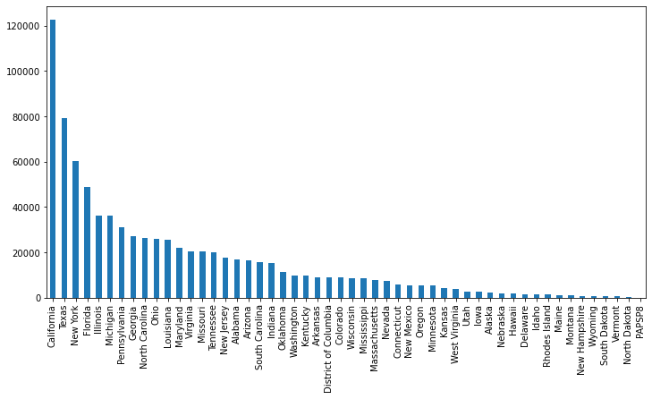

```python
# number of murders per state
plt.figure(figsize=(12, 6))
shr["State"].value_counts().plot.bar()
plt.show()
```

Let's visualise the number of murders per state on a map of the United States to see if any patterns emerge.

```python
# converting the value counts series to a dictionary
state_murders_dict = dict(shr["State"].value_counts())
```

```python
def style_function(feature):
    state = state_murders_dict.get(feature['properties']['name'])
    return {'fillColor': '#gray' if state is None else colormap(state),
            'fillOpacity': 0.6,
            'weight': 0.2}
```

```python
m = folium.Map(location=[48, -102], zoom_start=3)

url = ("https://raw.githubusercontent.com/python-visualization/folium/main/examples/data")
us_states = f"{url}/us-states.json"

colormap = cm.linear.Paired_12.scale(0, 122501)
colormap.add_to(m)

folium.GeoJson(
    data = us_states,
    style_function = style_function
    ).add_to(m)

m
```

[interactive chart not shown]

Let's take a closer look at the four states in our data that have seen the most homicides.

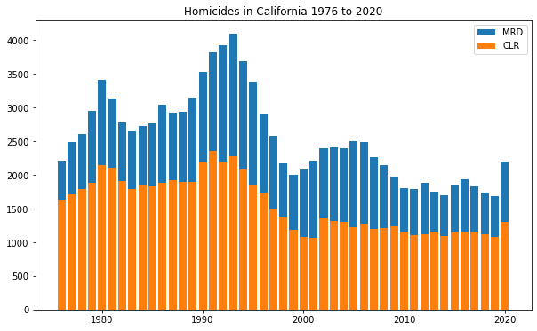

```
California - Cleared: 60.75%, Unsolved: 39.25%.
```

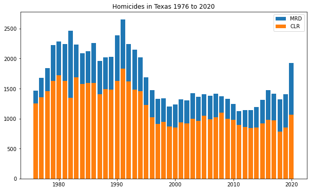

```
Texas - Cleared: 71.47%, Unsolved: 28.53%.
```

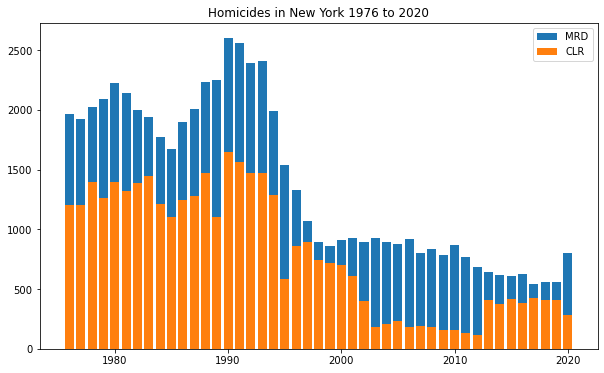

```
New York - Cleared: 57.95%, Unsolved: 42.05%.
```

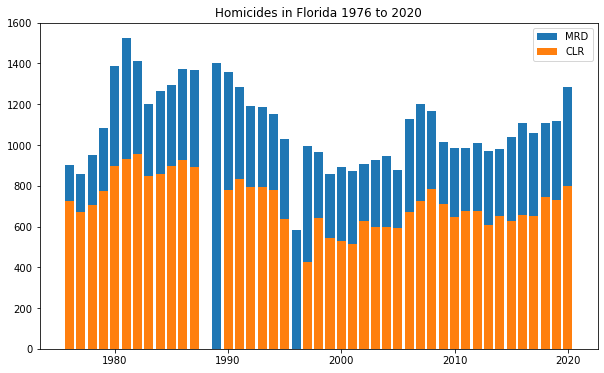

```
Florida - Cleared: 62.51%, Unsolved: 37.49%.
```

```python
for state in shr["State"].value_counts()[:4].index:

    state_ucr = ucr[(ucr["State"]==state) & (ucr["YEAR"] > 1975)]

    grouped = state_ucr.groupby("YEAR")[["MRD","CLR"]].agg(np.sum)
    plot_homicide_clearance(grouped, f"Homicides in {state} 1976 to 2020")

    percent_cleared = round(sum(state_ucr["CLR"]) / sum(state_ucr["MRD"]) * 100, 2)
    print(f"{state} - Cleared: {percent_cleared}%, Unsolved: {100-percent_cleared}%.")
```

#### Year

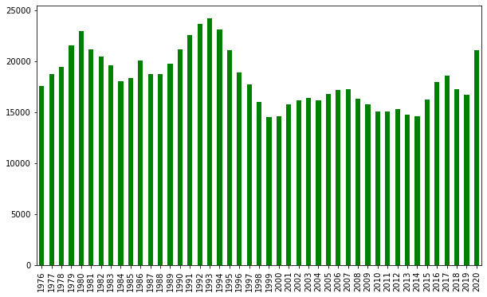

```python
# number of murders per year
plt.figure(figsize=(10, 6))
shr["Year"].value_counts().sort_index().plot.bar(color="g")
plt.show()
```

It looks like the 2019 to 2020 increase is the biggest from one year to another across all years in our data. Let's take a closer look.

```python
increase_dict = {}

for i in range(min(shr["Year"]), max(shr["Year"])):
    difference = shr["Year"].value_counts()[i+1] - shr["Year"].value_counts()[i]
    years = str(i) + "-" + str(i+1)
    increase_dict[years] = difference

increase_dict
```

```
{'1976-1977': 1191,
 '1977-1978': 703,
 '1978-1979': 2142,
 '1979-1980': 1413,
 '1980-1981': -1870,
 '1981-1982': -673,
 '1982-1983': -873,
 '1983-1984': -1555,
 '1984-1985': 289,
 '1985-1986': 1737,
 '1986-1987': -1340,
 '1987-1988': -1,
 '1988-1989': 1076,
 '1989-1990': 1380,
 '1990-1991': 1414,
 '1991-1992': 1118,
 '1992-1993': 539,
 '1993-1994': -1091,
 '1994-1995': -2057,
 '1995-1996': -2177,
 '1996-1997': -1183,
 '1997-1998': -1721,
 '1998-1999': -1452,
 '1999-2000': 68,
 '2000-2001': 1115,
 '2001-2002': 458,
 '2002-2003': 232,
 '2003-2004': -267,
 '2004-2005': 604,
 '2005-2006': 431,
 '2006-2007': 34,
 '2007-2008': -887,
 '2008-2009': -570,
 '2009-2010': -722,
 '2010-2011': -17,
 '2011-2012': 265,
 '2012-2013': -535,
 '2013-2014': -143,
 '2014-2015': 1650,
 '2015-2016': 1667,
 '2016-2017': 650,
 '2017-2018': -1342,
 '2018-2019': -504,
 '2019-2020': 4331}
```

```python
years = max(increase_dict, key=increase_dict.get)
increase = max(increase_dict.values())
print(f"The biggest increase in murders from one year to the next in our data is recorded from {years} with {increase} \
more murders in {years[5:]} than in {years[:4]}. This is an increase of \
{round(increase / len(shr[shr['Year']==2019]) * 100, 2)}%.")
```

```
The biggest increase in murders from one year to the next in our data is recorded from 2019-2020 with 4331 more murders in 2020 than in 2019. This is an increase of 25.81%.
```

```python
sorted_dict = dict(sorted(increase_dict.items(), key=operator.itemgetter(1), reverse=True))   # sorted dictionary
list(sorted_dict.items())[:4]   # converting to list to be able to slice
```

```
[('2019-2020', 4331),
 ('1978-1979', 2142),
 ('1985-1986', 1737),
 ('2015-2016', 1667)]
```

```python
print(f"This increase is over twice as large as the second largest increase recorded: {list(sorted_dict.items())[1][1]}, \
{list(sorted_dict.items())[1][0]}, {round(list(sorted_dict.items())[1][1] / len(shr[shr['Year']==1978]) * 100, 2)}% !")
```

```
This increase is over twice as large as the second largest increase recorded: 2142, 1978-1979, 11.0% !
```

Let's take a closer look at the 2020 homicides to search for clues that might help us explain the unprecedented spike.

```python
murders_2020 = shr[shr["Year"] == 2020]
murders_2020.sample(3)
```

|  | ID | CNTYFIPS | Ori | State | Agency | Agentype | Source | Solved | Year | StateName | Month | Incident | ActionType | Homicide | Situation | VicAge | VicSex | VicRace | VicEthnic | OffAge | OffSex | OffRace | OffEthnic | Weapon | Relationship | Circumstance | Subcircum | VicCount | OffCount | … |
| --- | --- | --- | --- | --- | --- | --- | --- | --- | --- | --- | --- | --- | --- | --- | --- | --- | --- | --- | --- | --- | --- | --- | --- | --- | --- | --- | --- | --- | --- | --- |
| 772431 | 202003001TX22009 | Tarrant, TX | TX22009 | Texas | Euless | Municipal police | FBI | Yes | 2020 | TEXAS | March | 1 | Normal update | Murder and non-negligent manslaughter | Single victim/single offender | 33 | Male | Black | Not of Hispanic origin | 25 | Male | Black | Not of Hispanic origin | Handgun - pistol, revolver, etc | Other - known to victim | Robbery | NaN | 0 | 0 | … |
| 250384 | 202003004GA04402 | De Kalb, GA | GA04402 | Georgia | Dekalb County Police Department | County police | FBI | Yes | 2020 | GEORGI | March | 4 | Normal update | Murder and non-negligent manslaughter | Multiple victims/multiple offenders | 93 | Male | Black | Not of Hispanic origin | 999 | Male | Black | Not of Hispanic origin | Firearm, type not stated | Relationship not determined | Circumstances undetermined | NaN | 3 | 1 | … |
| 453476 | 202011001MO04801 | Jackson, MO | MO04801 | Missouri | Blue Springs | Municipal police | FBI | Yes | 2020 | MISSOU | November | 1 | Normal update | Murder and non-negligent manslaughter | Single victim/multiple offenders | 19 | Male | Black | Not of Hispanic origin | 20 | Male | White | Not of Hispanic origin | Handgun - pistol, revolver, etc | Friend | Other | NaN | 0 | 2 | … |

To be able to compare 2020 information with previous years, we will also look at murder details from 2015, 2016, 2017, 2018 and 2019.

```python
murders_2019 = shr[shr["Year"] == 2019]
murders_2018 = shr[shr["Year"] == 2018]
murders_2017 = shr[shr["Year"] == 2017]
murders_2016 = shr[shr["Year"] == 2016]
murders_2015 = shr[shr["Year"] == 2015]
```

```python
# helper function to display dataframes side by side
from IPython.display import display_html

def display_side_by_side(*args, titles):
    html_str = ""
    for df, title in zip(args, titles):
        html_str += '<th>' + f'<h3>{title}</h3>' + df.to_html() + '</th>'
    display_html(html_str, raw=True)
```

```python
for col in ["State", "Month", "Weapon", "Relationship", "Circumstance"]:
    display_side_by_side(murders_2015[col].value_counts().to_frame()[:5],
                         murders_2016[col].value_counts().to_frame()[:5],
                         murders_2017[col].value_counts().to_frame()[:5],
                         murders_2018[col].value_counts().to_frame()[:5],
                         murders_2019[col].value_counts().to_frame()[:5],
                         murders_2020[col].value_counts().to_frame()[:5],
                         titles=["2015", "2016", "2017", "2018", "2019", "2020"])
```

2015

|  | State |
| --- | --- |
| California | 2037 |
| Texas | 1432 |
| Florida | 1196 |
| Pennsylvania | 701 |
| New York | 643 |

2016

|  | State |
| --- | --- |
| California | 2082 |
| Texas | 1589 |
| Florida | 1260 |
| Illinois | 1009 |
| Pennsylvania | 733 |

2017

|  | State |
| --- | --- |
| California | 1991 |
| Texas | 1577 |
| Florida | 1232 |
| Illinois | 846 |
| Pennsylvania | 805 |

2018

|  | State |
| --- | --- |
| California | 1873 |
| Texas | 1450 |
| Florida | 1278 |
| Illinois | 881 |
| Pennsylvania | 835 |

2019

|  | State |
| --- | --- |
| California | 1813 |
| Texas | 1540 |
| Florida | 1289 |
| Illinois | 798 |
| Missouri | 625 |

2020

|  | State |
| --- | --- |
| California | 2372 |
| Texas | 2132 |
| Florida | 1482 |
| Illinois | 1070 |
| Michigan | 844 |

2015

|  | Month |
| --- | --- |
| July | 1522 |
| August | 1509 |
| September | 1456 |
| December | 1440 |
| May | 1423 |

2016

|  | Month |
| --- | --- |
| August | 1672 |
| July | 1664 |
| October | 1608 |
| June | 1599 |
| November | 1549 |

2017

|  | Month |
| --- | --- |
| July | 1755 |
| October | 1667 |
| January | 1665 |
| May | 1608 |
| August | 1601 |

2018

|  | Month |
| --- | --- |
| July | 1599 |
| June | 1572 |
| January | 1518 |
| May | 1490 |
| August | 1485 |

2019

|  | Month |
| --- | --- |
| July | 1507 |
| May | 1496 |
| June | 1489 |
| August | 1461 |
| September | 1424 |

2020

|  | Month |
| --- | --- |
| July | 2079 |
| October | 2035 |
| August | 2032 |
| June | 1995 |
| September | 1899 |

2015

|  | Weapon |
| --- | --- |
| Handgun - pistol, revolver, etc | 7702 |
| Firearm, type not stated | 3193 |
| Knife or cutting instrument | 1765 |
| Other or type unknown | 1067 |
| Personal weapons, includes beating | 791 |

2016

|  | Weapon |
| --- | --- |
| Handgun - pistol, revolver, etc | 8433 |
| Firearm, type not stated | 3832 |
| Knife or cutting instrument | 1812 |
| Other or type unknown | 1073 |
| Personal weapons, includes beating | 809 |

2017

|  | Weapon |
| --- | --- |
| Handgun - pistol, revolver, etc | 8489 |
| Firearm, type not stated | 3934 |
| Knife or cutting instrument | 1834 |
| Other or type unknown | 1354 |
| Personal weapons, includes beating | 871 |

2018

|  | Weapon |
| --- | --- |
| Handgun - pistol, revolver, etc | 7945 |
| Firearm, type not stated | 3661 |
| Knife or cutting instrument | 1706 |
| Other or type unknown | 1272 |
| Personal weapons, includes beating | 837 |

2019

|  | Weapon |
| --- | --- |
| Handgun - pistol, revolver, etc | 7482 |
| Firearm, type not stated | 3837 |
| Knife or cutting instrument | 1637 |
| Other or type unknown | 1398 |
| Personal weapons, includes beating | 747 |

2020

|  | Weapon |
| --- | --- |
| Handgun - pistol, revolver, etc | 9264 |
| Firearm, type not stated | 5538 |
| Knife or cutting instrument | 1927 |
| Other or type unknown | 1689 |
| Personal weapons, includes beating | 793 |

2015

|  | Relationship |
| --- | --- |
| Relationship not determined | 7816 |
| Acquaintance | 2072 |
| Stranger | 1976 |
| Other - known to victim | 1043 |
| Girlfriend | 559 |

2016

|  | Relationship |
| --- | --- |
| Relationship not determined | 8977 |
| Acquaintance | 2214 |
| Stranger | 2153 |
| Other - known to victim | 1085 |
| Wife | 557 |

2017

|  | Relationship |
| --- | --- |
| Relationship not determined | 9314 |
| Acquaintance | 2283 |
| Stranger | 2136 |
| Other - known to victim | 1090 |
| Wife | 606 |

2018

|  | Relationship |
| --- | --- |
| Relationship not determined | 8625 |
| Stranger | 1995 |
| Acquaintance | 1934 |
| Other - known to victim | 1020 |
| Wife | 602 |

2019

|  | Relationship |
| --- | --- |
| Relationship not determined | 8274 |
| Stranger | 1958 |
| Acquaintance | 1956 |
| Other - known to victim | 1021 |
| Wife | 562 |

2020

|  | Relationship |
| --- | --- |
| Relationship not determined | 11091 |
| Stranger | 2461 |
| Acquaintance | 2320 |
| Other - known to victim | 1238 |
| Girlfriend | 609 |

2015

|  | Circumstance |
| --- | --- |
| Circumstances undetermined | 5596 |
| Other arguments | 3152 |
| Other | 2002 |
| Other - not specified | 1453 |
| Robbery | 629 |

2016

|  | Circumstance |
| --- | --- |
| Circumstances undetermined | 6258 |
| Other arguments | 3389 |
| Other | 2314 |
| Other - not specified | 1501 |
| Robbery | 763 |

2017

|  | Circumstance |
| --- | --- |
| Circumstances undetermined | 6414 |
| Other arguments | 3380 |
| Other | 2561 |
| Other - not specified | 1493 |
| Robbery | 718 |

2018

|  | Circumstance |
| --- | --- |
| Circumstances undetermined | 5756 |
| Other arguments | 3330 |
| Other | 2330 |
| Other - not specified | 1440 |
| Narcotic drug laws | 623 |

2019

|  | Circumstance |
| --- | --- |
| Circumstances undetermined | 5794 |
| Other arguments | 3417 |
| Other | 2050 |
| Other - not specified | 1280 |
| All other manslaughter by negligence | 687 |

2020

|  | Circumstance |
| --- | --- |
| Circumstances undetermined | 8112 |
| Other arguments | 4017 |
| Other | 2779 |
| Other - not specified | 1267 |
| All other manslaughter by negligence | 982 |

Looking at the `State`, `Month`, `Weapon`, `Relationship` and `Circumstance` columns, the patterns in our data don't appear to have changed from previous years - the 2020 numbers are just higher.

Let's try looking at some additional columns.

```python
df_2015_to_2020 = shr[shr["Year"].isin(["2015", "2016", "2017", "2018", "2019", "2020"])]
```

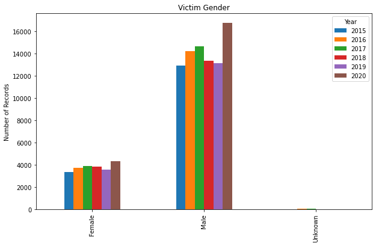

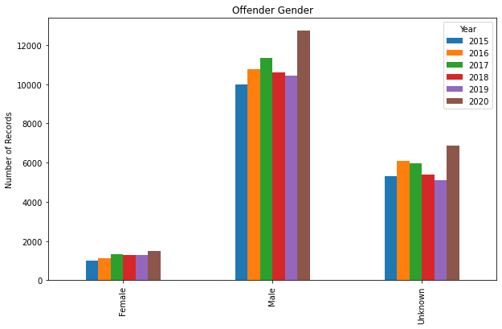

```python
# gender columns
cols = ["VicSex", "OffSex"]
titles = ["Victim Gender", "Offender Gender"]
i = 0

for col in cols:
    df_2015_to_2020.groupby([col, "Year"]).size().unstack(level=1).plot(kind="bar", xlabel="", ylabel="Number of Records",
                                                                        figsize=(10,6), title=titles[i])
    i+=1
```

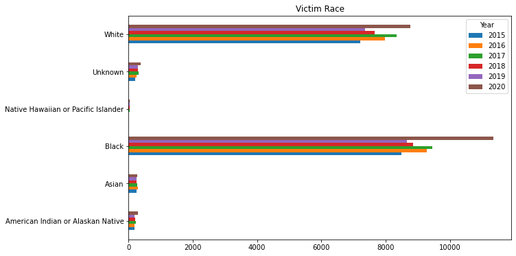

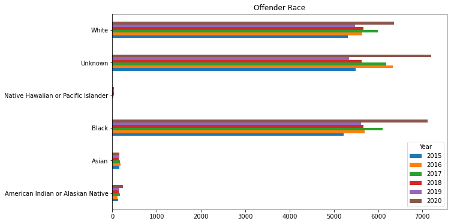

```python
# race columns
cols = ["VicRace", "OffRace"]
titles = ["Victim Race", "Offender Race"]
i = 0

for col in cols:
    df_2015_to_2020.groupby([col, "Year"]).size().unstack(level=1).plot(kind="barh", xlabel="", ylabel="Number of Records",
                                                                        figsize=(10,6), title=titles[i])
    i+=1
```

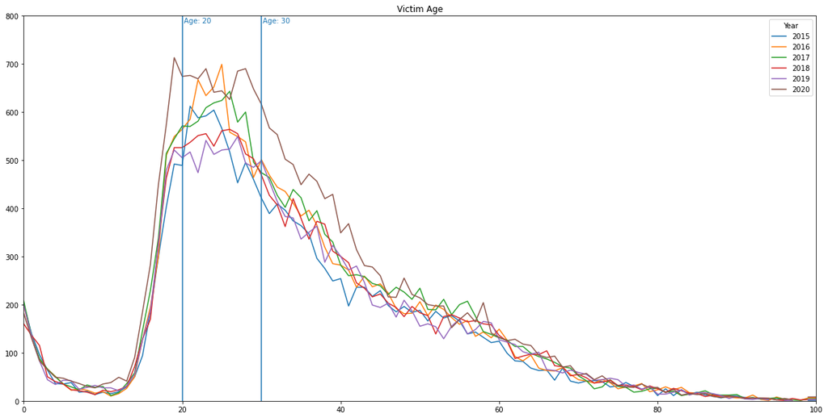

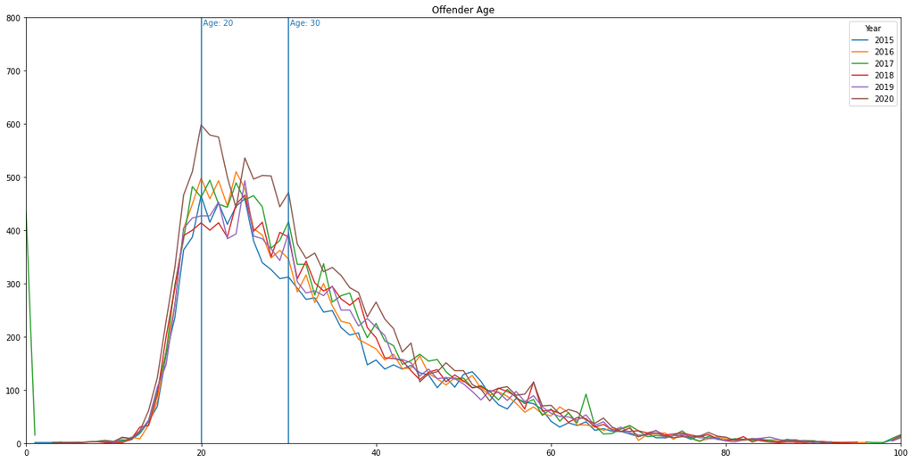

```python
# age columns - we are not plotting age 999, used to represent unknown
age_titles = ["Victim Age", "Offender Age"]
i = 0

for col in ["VicAge", "OffAge"]:

    df_2015_to_2020.groupby([col, "Year"]).size().unstack(level=1).plot(kind="line", xlabel="", ylabel="", xlim=[0,100],
                                                                        ylim=[0,800], figsize=(20,10), title=age_titles[i])
    i+=1

    plt.axvline(x=20)
    plt.axvline(x=30)

    plt.text(20.2, 785, "Age: 20", color="#1f77b4")
    plt.text(30.2, 785, "Age: 30", color="#1f77b4")
```

Looking at patterns, we again find that the 2020 data is very similar to the details reported for previous years. It turns out that identifying the change in murder rate is easy compared to figuring out why the increase occurred. We might have to look beyond our data for further insights.

Additional research using the [MAP website](http://www.murderdata.org/) and other news articles online (i.e. [this "The Intercept" article](https://theintercept.com/2021/02/21/2020-murder-homicide-rate-causes/)) suggests that there were a number of contributing factors that led to the big 2020 murder spike. The most important are believed to be the Covid-19 pandemic, the public outrage over the murder of George Floyd and widespread demonstrations on behalf of the Black Lives Matter movement, and a sudden influx in firearms followed by a higher percentage of crimes being committed with guns, causing more deaths.

To tie this back to our earlier findings - the 2020 spike in homicides and low in murder clearance rates are likely interrelated, as one can imagine the nation's understaffed police and sheriff's departments struggling to keep up with the unusually high number of murders needing to be investigated, while also having to deal with the pandemic and the changes to the public's perception of police legitimacy.